# Trees, forests, networks

## Preparing the environment

#### Install and/or load the packages

```r
loading.packages <- function(warn = FALSE) {
if(!require(package = "e1071", quietly = T, warn.conflicts = F)){
  install.packages("e1071")}
if(!require(package = "caret", quietly = T, warn.conflicts = F)){
  install.packages("caret")}
if(!require(package = "randomForest", quietly = T, warn.conflicts = F)){
  install.packages("randomForest")}
if(!require(package = "neuralnet", quietly = T, warn.conflicts = F)){
  install.packages("neuralnet")}
if(!require(package = "grid", quietly = T, warn.conflicts = F)){
  install.packages("grid")} # For neuralnet plots
if(!require(package = "gplots", quietly = T, warn.conflicts = F)){
  install.packages("gplots")} # For heatmaps
}
# This resource helps to keep the Rmarkdown free of cluttering messages - use it only if you are sure that the warnings and messages are not critical
suppressWarnings(suppressMessages(loading.packages()))
```

#### Load iris dataset

```r
data(iris)
iris.data <- subset(x = iris, select = -Species)
iris.species <- subset(x = iris, select = Species)
iris.species <- iris.species$Species
```

#### Set the seed

```r
set.seed(seed = 2545846)
```

## 1 - SVM

#### Computing SVMs

```r
suppressWarnings(suppressMessages(library(e1071)))
suppressWarnings(suppressMessages(library(dplyr)))
model.svm <- svm(x = iris.data, y = iris.species, type="C")
```

#### Computing and Plotting PCA

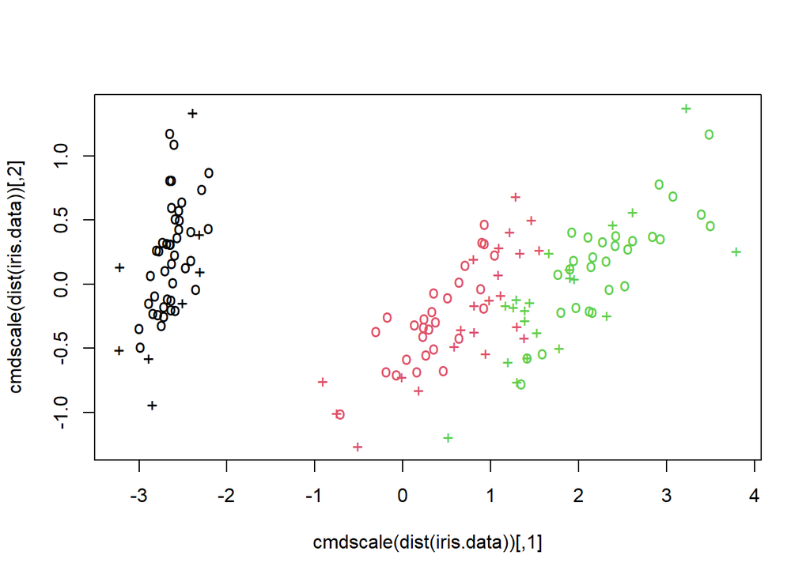

```r
plot(cmdscale(dist(iris.data)),
     col = as.integer(iris.species),
     pch = c("o","+")[1:150 %in% model.svm$index + 1])
```

You should have created a plot of the iris dataset with the classification parameters learned by the algorithm. What do the “+” characters on the plot represent?

#### Use the model to classify the iris data:

```r
pred <- predict(model.svm, iris.data)
table(pred, iris.species)
```

```
##             iris.species
## pred         setosa versicolor virginica
##   setosa         50          0         0
##   versicolor      0         48         2
##   virginica       0          2        48
```

What are the false positive, false negative, true positive and true negative rates for classification using this model? … we can’t really tell properly as we trained on the same data we classified.

#### Let’s load some new packages:

```r
suppressWarnings(suppressMessages(library(randomForest)))
suppressWarnings(suppressMessages(library(caret)))
```

#### Now we will split the data into learning and training data

```r
# Creating a vector for sub-setting the iris dataset

iris.indexes <- createDataPartition(iris$Species, p = 0.7, list = FALSE)

# Subsetting the iris dataset

train <- iris[iris.indexes, ]
test <- iris[-iris.indexes, ]
train.data <- subset(x = train, select = -Species)
train.species <- subset(x = train, select = Species)
train.species <- train.species$Species
test.data <- subset(x = test, select = -Species)
test.species <- subset(x = test, select = Species)
test.species <- test.species$Species
```

#### Train on part of the data, classify on the other part

```r
model.svm <- svm(x = train.data, y = train.species, type="C")
pred <- predict(model.svm, test.data)
```

#### Print “confusion matrix”

```r
table(pred, test.species)
```

```
##             test.species
## pred         setosa versicolor virginica
##   setosa         15          0         0
##   versicolor      0         13         1
##   virginica       0          2        14
```

## 2 - Random Forest

Let’s perform data classification in subsets of iris dataset using Random Forests

#### Loading the packages

```r
suppressWarnings(suppressMessages(library(randomForest)))
suppressWarnings(suppressMessages(library(gplots)))
```

#### Preparing the subsets

Let’s suppose we have two subsets of the iris dataset: training set and testing set. The iris dataset contains 150 rows. The training and testing sets will contain a fraction of the original dataset. The 5th column in the iris dataset contains the species information. However, for this example, let’s suppose we don’t have the species information for the “testing set”. So we will remove it, and try to recover that information using the RF algorithm.

```r
# Creating the training set

iris.training.set <- train

# Creating the testing set - the "Species" column will be removed from the iris testing set (masked)

iris.testing.set <- test
iris.masked.tgt.set <- subset(x = iris.testing.set, select = -c(Species))
iris.tgt.spec.info <- iris.testing.set[,5]
```

#### Performing the Random Forest algorithm

The command below will perform the random forest algorithm. The parameters are similar to those used to construct the model in the class about linear regression. The parameter **x** contains the matrix of predictors and the parameter **y** contains the response variable.

```r
iris.RF <- randomForest(x = iris.training.set[,-5],
                             y = as.factor(iris.training.set[,5]))

# Note: Since the parameter "y" is a factor, the algorithm will perform classification
```

#### Evaluating the model

```r
print(iris.RF)
```

```
##
## Call:
##  randomForest(x = iris.training.set[, -5], y = as.factor(iris.training.set[,      5]))
##                Type of random forest: classification
##                      Number of trees: 500
## No. of variables tried at each split: 2
##
##         OOB estimate of  error rate: 2.86%
## Confusion matrix:
##            setosa versicolor virginica class.error
## setosa         35          0         0  0.00000000
## versicolor      0         34         1  0.02857143
## virginica       0          2        33  0.05714286
```

#### Classifying the iris testing set

Since we established the model using the command **randomForest**, we can predict the values (species) in the **iris testing set** - a subset containing only a % of the original iris data set - using the command **predict**.

```r
iris.pred.tgt.species <- predict(object = iris.RF, newdata = iris.masked.tgt.set)
```

#### Extracting and visualizing the confusion matrix

Let’s evaluate our data classification using a confusion matrix.

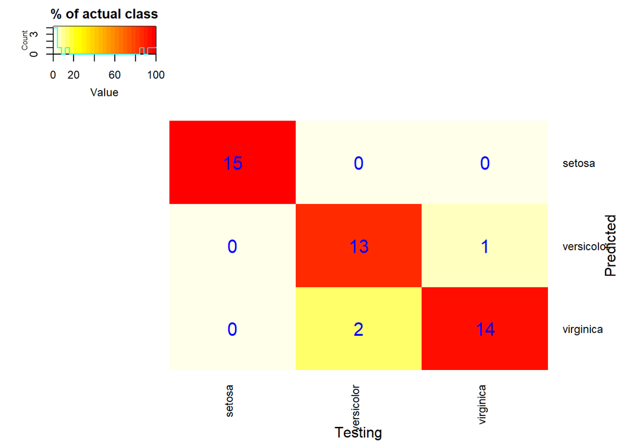

```r
# Creating the confusion matrix

iris.confusion.matrix <- table(testing = iris.tgt.spec.info, predicted = iris.pred.tgt.species)

# Reformatting the confusion matrix to produce the heatmaps

df.iris.confusion.matrix <- data.frame(rbind(iris.confusion.matrix))

# Since the sample sizes by class are not balanced, the heatmap colors will represent the % of true testing values

normalized.iris.confusion.matrix <- apply(X = df.iris.confusion.matrix, MARGIN = 1, FUN = function(x) c(x/sum(x))*100)

# Visualising the confusion matrix heatmap

heatmap.2(x = normalized.iris.confusion.matrix,
          col = rev(heat.colors(25)),
          Rowv = FALSE,
          Colv = FALSE,
          dendrogram = "none",
          trace = "none",
          cellnote = t(iris.confusion.matrix),
          notecol = "blue",
          notecex = 1.5,
          key.title = "% of actual class",
          cexRow = 0.9,
          cexCol = 0.9,
          xlab = "Testing",
          ylab = "Predicted")
```

## 3 - The “caret” method

```r
tc <- trainControl(method = "repeatedcv", number = 10, repeats = 3)

cmodel <- train(Species~., data=train, method="rf", trControl=tc)
print(cmodel)
```

```
## Random Forest
##
## 105 samples
##   4 predictor
##   3 classes: 'setosa', 'versicolor', 'virginica'
##
## No pre-processing
## Resampling: Cross-Validated (10 fold, repeated 3 times)
## Summary of sample sizes: 93, 95, 94, 95, 96, 95, ...
## Resampling results across tuning parameters:
##
##   mtry  Accuracy   Kappa
##   2     0.9507576  0.9260752
##   3     0.9565657  0.9347686
##   4     0.9565657  0.9347686
##
## Accuracy was used to select the optimal model using the largest value.
## The final value used for the model was mtry = 3.
```

```r
cpred <- predict(cmodel, test)
cm <- confusionMatrix(test$Species, cpred)
print(cm)
```

```
## Confusion Matrix and Statistics
##
##             Reference
## Prediction   setosa versicolor virginica
##   setosa         15          0         0
##   versicolor      0         14         1
##   virginica       0          1        14
##
## Overall Statistics
##
##                Accuracy : 0.9556
##                  95% CI : (0.8485, 0.9946)
##     No Information Rate : 0.3333
##     P-Value [Acc > NIR] : < 2.2e-16
##
##                   Kappa : 0.9333
##
##  Mcnemar's Test P-Value : NA
##
## Statistics by Class:
##
##                      Class: setosa Class: versicolor Class: virginica
## Sensitivity                 1.0000            0.9333           0.9333
## Specificity                 1.0000            0.9667           0.9667
## Pos Pred Value              1.0000            0.9333           0.9333
## Neg Pred Value              1.0000            0.9667           0.9667
## Prevalence                  0.3333            0.3333           0.3333
## Detection Rate              0.3333            0.3111           0.3111
## Detection Prevalence        0.3333            0.3333           0.3333
## Balanced Accuracy           1.0000            0.9500           0.9500
```

## 4 - Neural networks

#### OK, now let’s try neural nets

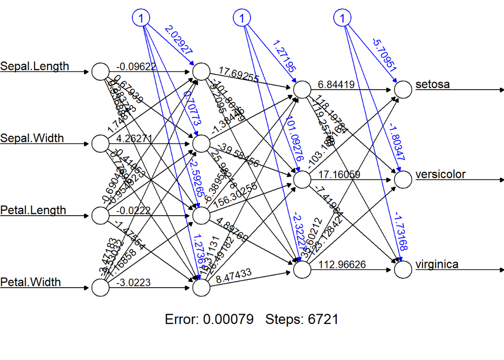

```r
# The package neuralnet will be used to train the neural networks

suppressWarnings(suppressMessages(library(neuralnet)))

# The package grid will be used to visualise the neural networks

suppressWarnings(suppressMessages(library(grid)))

# Extracting the data points from the testing subset

xtest <- test[, -5]

# Extracting the Species information from the testing subset

ytest <- test[, 5]

# Training the neural networks

nnet <- neuralnet(Species~., train, hidden = c(4,3), linear.output = FALSE)

# Neural nets are constructed as grid graphical object (grob). The package grid allows us to draw the neural nets

nnet.plot <- grid.grabExpr(expr = plot(nnet), wrap = TRUE, wrap.grobs = TRUE)
grid.draw(nnet.plot)
```

#### And try classifying with it

```r
ypred <- neuralnet::compute(nnet, xtest)

yhat <- ypred$net.result
print(yhat)
```

```
##             [,1]         [,2]         [,3]
## 4   1.000000e+00 1.188295e-03 3.276902e-04
## 8   1.000000e+00 1.188295e-03 3.276902e-04
## 18  1.000000e+00 1.188295e-03 3.276902e-04
## 19  1.000000e+00 1.188295e-03 3.276902e-04
## 20  1.000000e+00 1.188295e-03 3.276902e-04
## 21  1.000000e+00 1.188295e-03 3.276902e-04
## 24  1.000000e+00 1.188295e-03 3.276902e-04
## 26  1.000000e+00 1.188295e-03 3.276902e-04
## 28  1.000000e+00 1.188295e-03 3.276902e-04
## 29  1.000000e+00 1.188295e-03 3.276902e-04
## 32  1.000000e+00 1.188295e-03 3.276902e-04
## 33  1.000000e+00 1.188295e-03 3.276902e-04
## 43  1.000000e+00 1.188295e-03 3.276902e-04
## 48  1.000000e+00 1.188295e-03 3.276902e-04
```

[output cut: 31 more lines]